# trial counts

mike freund

2020-11-09

Examining trial numbers per subject*run and per various stratifications of (potential) conditions of interest. Within each task.

# 1 AXCPT

## 1.1 potential task variables

- cue type (‘context’): A, B
- probe type (‘context’): X, Y, nogo (number)
- cue ID (letter): A, C, D, F, H, M, N, P, T, U
- probe ID (alnum): 1, 2, 3, 4, 5, 6, 7, 8, 9, C, D, F, H, M, N, P, T, U, X
- response: left (AX) - right (AY, BX, BY)
- hi/lo: AX/BY
- go/nogo: (AX, AY, BX, BY) - (Ang, Bng)

## 1.2 counts

Counts per subject*run.

```r
colMeans(with(axcpt, table(interaction(subj, run), trial.type))) %>%
  kable(col.names = "count", caption = "cue \\* probe type")
```

cue * probe type

|  | count |
| --- | --- |
| Ang | 6 |
| AX | 24 |
| AY | 6 |
| Bng | 6 |
| BX | 6 |
| BY | 24 |

```r
axcpt.cue <- as.matrix(with(axcpt, table(interaction(subj, run), cue)))

data.frame(
  mean_count = colMeans(axcpt.cue),
  min = apply(axcpt.cue, 2, min),
  max = apply(axcpt.cue, 2, max)
  ) %>%
  kable(caption = "cue ID")
```

cue ID

|  | mean_count | min | max |
| --- | --- | --- | --- |
| A | 36.000 | 36 | 36 |
| C | 3.982 | 2 | 7 |
| D | 4.191 | 2 | 7 |
| F | 3.964 | 2 | 7 |
| H | 4.109 | 2 | 7 |
| M | 3.964 | 2 | 6 |
| N | 4.045 | 2 | 8 |
| P | 4.009 | 2 | 6 |
| T | 3.991 | 2 | 7 |
| U | 3.745 | 2 | 7 |

```r
axcpt.probe <- as.matrix(with(axcpt, table(interaction(subj, run), probe)))

data.frame(
  mean_count = colMeans(axcpt.probe),
  min = apply(axcpt.probe, 2, min),
  max = apply(axcpt.probe, 2, max)
  ) %>%
  kable(caption = "probe ID")
```

probe ID

|  | mean_count | min | max |
| --- | --- | --- | --- |
| 1 | 1.282 | 0 | 4 |
| 2 | 1.364 | 0 | 4 |
| 3 | 1.355 | 0 | 3 |
| 4 | 1.382 | 0 | 3 |
| 5 | 1.246 | 0 | 5 |
| 6 | 1.546 | 0 | 4 |
| 7 | 1.164 | 0 | 3 |
| 8 | 1.418 | 0 | 4 |
| 9 | 1.246 | 0 | 4 |
| C | 3.300 | 1 | 7 |
| D | 3.364 | 2 | 5 |
| F | 3.209 | 1 | 7 |
| H | 3.409 | 2 | 6 |
| M | 3.209 | 1 | 7 |
| N | 3.409 | 2 | 6 |
| P | 3.300 | 2 | 6 |
| T | 3.509 | 2 | 6 |
| U | 3.291 | 2 | 5 |
| X | 30.000 | 30 | 30 |

```r
axcpt$cuetype <- ifelse(axcpt$cue == "A", "A", "B")
axcpt.cueprobe <- with(axcpt, table(interaction(subj, run), interaction(cuetype, probe)))

data.frame(
  mean_count = colMeans(axcpt.cueprobe),
  min = apply(axcpt.cueprobe, 2, min),
  max = apply(axcpt.cueprobe, 2, max)
  ) %>%
  kable(caption = "cuetype \\* probeID")
```

cuetype * probeID

|  | mean_count | min | max |
| --- | --- | --- | --- |
| A.1 | 0.6091 | 0 | 2 |
| B.1 | 0.6727 | 0 | 4 |
| A.2 | 0.7545 | 0 | 2 |
| B.2 | 0.6091 | 0 | 2 |
| A.3 | 0.6182 | 0 | 2 |
| B.3 | 0.7364 | 0 | 2 |
| A.4 | 0.7364 | 0 | 2 |
| B.4 | 0.6455 | 0 | 3 |
| A.5 | 0.6273 | 0 | 2 |
| B.5 | 0.6182 | 0 | 3 |
| A.6 | 0.7545 | 0 | 2 |
| B.6 | 0.7909 | 0 | 2 |
| A.7 | 0.5818 | 0 | 2 |
| B.7 | 0.5818 | 0 | 2 |
| A.8 | 0.7545 | 0 | 2 |
| B.8 | 0.6636 | 0 | 2 |
| A.9 | 0.5636 | 0 | 2 |
| B.9 | 0.6818 | 0 | 3 |
| A.C | 0.5818 | 0 | 2 |
| B.C | 2.7182 | 1 | 5 |
| A.D | 0.7364 | 0 | 2 |
| B.D | 2.6273 | 2 | 4 |
| A.F | 0.6091 | 0 | 2 |
| B.F | 2.6000 | 1 | 6 |
| A.H | 0.7364 | 0 | 2 |
| B.H | 2.6727 | 1 | 6 |
| A.M | 0.5909 | 0 | 2 |
| B.M | 2.6182 | 0 | 7 |
| A.N | 0.7455 | 0 | 2 |
| B.N | 2.6636 | 2 | 4 |
| A.P | 0.6091 | 0 | 2 |
| B.P | 2.6909 | 1 | 6 |
| A.T | 0.7818 | 0 | 2 |
| B.T | 2.7273 | 2 | 4 |
| A.U | 0.6091 | 0 | 2 |
| B.U | 2.6818 | 2 | 4 |
| A.X | 24.0000 | 24 | 24 |
| B.X | 6.0000 | 6 | 6 |

- Good number of each cue and probe letter (except for #s, which are sparse)
  - context (cue type), hi/lo, motor, gonogo
- not when moving to cue*probe ID combos

# 2 CUEDTS

## 2.1 potential task variables

- task cue (‘rule’): letter, number
- sequence: switch, stay (i.e., repeat)
- response: left, right
- hi/lo (congruency): incon (EC, OV), congr (EV, OC)
- probe (stimulus) type: (letter type)(number type) = (V, C)(E, O)
- probe (stimulus) ID: (letter ID)(number ID)
  - (A, B, D, E, H, I)*(1, 2, 3, 4, 5, 6)
  - can indicate order (i.e., spatial location), or not (i.e., simply combo/presence of letter, indep. of location)

## 2.2 counts

relatively abstract factors:

```r
cuedts <- as.data.frame(cuedts)

colMeans(with(cuedts, table(interaction(subj, run), trial.type))) %>%
  kable(col.names = "count", caption = "trialtype (hi/lo)")
```

trialtype (hi/lo)

|  | count |
| --- | --- |
| Con | 35 |
| InCon | 19 |

```r
cuedts.ts <- with(cuedts[cuedts$switch != "", ], table(interaction(subj, run), interaction(cue, switch)))
data.frame(
  mean_count = colMeans(cuedts.ts),
  min = apply(cuedts.ts, 2, min),
  max = apply(cuedts.ts, 2, max)
  ) %>%
  kable(caption = "cue \\* switch")
```

cue * switch

|  | mean_count | min | max |
| --- | --- | --- | --- |
| l.Repeat | 12.10 | 7 | 16 |
| n.Repeat | 12.02 | 8 | 17 |
| l.Switch | 13.38 | 9 | 17 |
| n.Switch | 13.50 | 9 | 19 |

```r
cuedts.tst <- with(cuedts[cuedts$switch != "", ], table(interaction(subj, run), interaction(cue, switch, trial.type)))
data.frame(
  mean_count = colMeans(cuedts.tst),
  min = apply(cuedts.tst, 2, min),
  max = apply(cuedts.tst, 2, max)
  ) %>%
  kable(caption = "cue \\* trial.type \\* switch")
```

cue * trial.type * switch

|  | mean_count | min | max |
| --- | --- | --- | --- |
| l.Repeat.Con | 7.755 | 4 | 14 |
| n.Repeat.Con | 7.664 | 4 | 12 |
| l.Switch.Con | 8.682 | 3 | 13 |
| n.Switch.Con | 8.818 | 5 | 13 |
| l.Repeat.InCon | 4.346 | 1 | 7 |
| n.Repeat.InCon | 4.354 | 1 | 8 |
| l.Switch.InCon | 4.700 | 2 | 8 |
| n.Switch.InCon | 4.682 | 1 | 9 |

```r
cuedts.tlns <- with(cuedts[cuedts$switch != "", ], table(interaction(subj, run), interaction(cue, letter, number, switch)))
data.frame(
  mean_count = colMeans(cuedts.tlns),
  min = apply(cuedts.tlns, 2, min),
  max = apply(cuedts.tlns, 2, max)
  ) %>%
  kable(caption = "cue \\* probetype \\* switch")
```

cue * probetype * switch

|  | mean_count | min | max |
| --- | --- | --- | --- |
| l.c.e.Repeat | 2.245 | 0 | 5 |
| n.c.e.Repeat | 2.082 | 0 | 5 |
| l.v.e.Repeat | 3.146 | 1 | 6 |
| n.v.e.Repeat | 4.400 | 1 | 8 |
| l.c.o.Repeat | 4.609 | 0 | 10 |
| n.c.o.Repeat | 3.264 | 0 | 7 |
| l.v.o.Repeat | 2.100 | 0 | 5 |
| n.v.o.Repeat | 2.273 | 0 | 5 |
| l.c.e.Switch | 2.554 | 0 | 6 |
| n.c.e.Switch | 2.245 | 0 | 5 |
| l.v.e.Switch | 3.864 | 1 | 7 |
| n.v.e.Switch | 4.991 | 2 | 8 |
| l.c.o.Switch | 4.818 | 0 | 9 |
| n.c.o.Switch | 3.827 | 1 | 8 |
| l.v.o.Switch | 2.146 | 0 | 5 |
| n.v.o.Switch | 2.436 | 0 | 5 |

```r
cuedts.tln <- with(cuedts, table(interaction(subj, run), interaction(cue, letter, number)))
data.frame(
  mean_count = colMeans(cuedts.tln),
  min = apply(cuedts.tln, 2, min),
  max = apply(cuedts.tln, 2, max)
  ) %>%
  kable(caption = "cue \\* probetype")
```

cue * probetype

|  | mean_count | min | max |
| --- | --- | --- | --- |
| l.c.e | 5.0 | 4 | 6 |
| n.c.e | 4.5 | 4 | 5 |
| l.v.e | 7.5 | 7 | 8 |
| n.v.e | 10.0 | 10 | 10 |
| l.c.o | 10.0 | 10 | 10 |
| n.c.o | 7.5 | 7 | 8 |
| l.v.o | 4.5 | 4 | 5 |
| n.v.o | 5.0 | 4 | 6 |

```r
cuedts.tir <- with(cuedts[cuedts$switch != "", ], table(interaction(subj, run), interaction(cue, trial.type, cresp)))
data.frame(
  mean_count = colMeans(cuedts.tir),
  min = apply(cuedts.tir, 2, min),
  max = apply(cuedts.tir, 2, max)
  ) %>%
  kable(caption = "cue \\* trial.type \\* cresp")
```

cue * trial.type * cresp

|  | mean_count | min | max |
| --- | --- | --- | --- |
| l.Con.1 | 7.009 | 5 | 8 |
| n.Con.1 | 9.391 | 7 | 10 |
| l.InCon.1 | 4.245 | 3 | 5 |
| n.InCon.1 | 4.327 | 3 | 5 |
| l.Con.2 | 9.427 | 8 | 10 |
| n.Con.2 | 7.091 | 5 | 8 |
| l.InCon.2 | 4.800 | 2 | 6 |
| n.InCon.2 | 4.709 | 3 | 6 |

stimulus (probe) ID factors:

```r
## probe ID ingoring spatial position

cuedts$stimuli.sort <- paste0(gsub("[A-Z]", "", cuedts$stimuli), gsub("[0-9]", "", cuedts$stimuli))


cuedts.probeidcue <- with(cuedts, table(interaction(subj, run), interaction(stimuli.sort, cue)))

data.frame(
  mean_count = colMeans(cuedts.probeidcue),
  min = apply(cuedts.probeidcue, 2, min),
  max = apply(cuedts.probeidcue, 2, max)
  ) %>%
  kable(caption = "probe ID (position-invariant)\\*task cue")
```

probe ID (position-invariant)*task cue

|  | mean_count | min | max |
| --- | --- | --- | --- |
| 1A.l | 1.0 | 1 | 1 |
| 1B.l | 6.0 | 6 | 6 |
| 2A.l | 5.0 | 5 | 5 |
| 2B.l | 1.5 | 1 | 2 |
| 3E.l | 3.5 | 3 | 4 |
| 4D.l | 3.5 | 3 | 4 |
| 5H.l | 4.0 | 4 | 4 |
| 6I.l | 2.5 | 2 | 3 |
| 1A.n | 1.5 | 1 | 2 |
| 1B.n | 5.0 | 5 | 5 |
| 2A.n | 6.0 | 6 | 6 |
| 2B.n | 1.0 | 1 | 1 |
| 3E.n | 3.5 | 3 | 4 |
| 4D.n | 3.5 | 3 | 4 |
| 5H.n | 2.5 | 2 | 3 |
| 6I.n | 4.0 | 4 | 4 |

```r
## probe ID by feature, ignoring spatial position

cuedts$stimuli.letter <- gsub("[0-9]", "", cuedts$stimuli)
cuedts.ltypecue <- with(cuedts, table(interaction(subj, run), interaction(stimuli.letter, cue)))

data.frame(
  mean_count = colMeans(cuedts.ltypecue),
  min = apply(cuedts.ltypecue, 2, min),
  max = apply(cuedts.ltypecue, 2, max)
  ) %>%
  kable(caption = "probe-letter type(position-invariant) \\* task cue")
```

probe-letter type(position-invariant) * task cue

|  | mean_count | min | max |
| --- | --- | --- | --- |
| A.l | 6.0 | 6 | 6 |
| B.l | 7.5 | 7 | 8 |
| D.l | 3.5 | 3 | 4 |
| E.l | 3.5 | 3 | 4 |
| H.l | 4.0 | 4 | 4 |
| I.l | 2.5 | 2 | 3 |
| A.n | 7.5 | 7 | 8 |
| B.n | 6.0 | 6 | 6 |
| D.n | 3.5 | 3 | 4 |
| E.n | 3.5 | 3 | 4 |
| H.n | 2.5 | 2 | 3 |
| I.n | 4.0 | 4 | 4 |

```r
cuedts$stimuli.number <- gsub("[A-Z]", "", cuedts$stimuli)
cuedts.ntypecue <- with(cuedts, table(interaction(subj, run), interaction(stimuli.number, cue)))

data.frame(
  mean_count = colMeans(cuedts.ntypecue),
  min = apply(cuedts.ntypecue, 2, min),
  max = apply(cuedts.ntypecue, 2, max)
  ) %>%
  kable(caption = "probe-number type(position-invariant) \\* task cue")
```

probe-number type(position-invariant) * task cue

|  | mean_count | min | max |
| --- | --- | --- | --- |
| 1.l | 7.0 | 7 | 7 |
| 2.l | 6.5 | 6 | 7 |
| 3.l | 3.5 | 3 | 4 |
| 4.l | 3.5 | 3 | 4 |
| 5.l | 4.0 | 4 | 4 |
| 6.l | 2.5 | 2 | 3 |
| 1.n | 6.5 | 6 | 7 |
| 2.n | 7.0 | 7 | 7 |
| 3.n | 3.5 | 3 | 4 |
| 4.n | 3.5 | 3 | 4 |
| 5.n | 2.5 | 2 | 3 |
| 6.n | 4.0 | 4 | 4 |

- probe features (stimuli ID) occurr in all subj*runs
- but not in all tasks
- problem can be fixed by ignoring order (spatial locations) of probe features
- stimulus feature model could also be fit (cross-task decoding of stimulus ID, spatially invariant)
  - would need to check if other factors are correlated with stim ID, though! (split each cell by I/C, S/R)

## 2.3 correlations

How are cuedts factors interrelated?

```r
cols.strings <- c("cue", "cresp", "switch", "trial.type", "letter", "number", "stimuli.letter", "stimuli.number")
cols.facts <- c(
  "task_letter", "task_number", "resp_L", "resp_R", "seq_switch", "seq_stay", "tt_congr", "tt_incon",
  "letter_conso", "letter_vowel", "number_even", "number_odd",
  "A", "B", "D", "E", "H", "I", "1", "2", "3", "4", "5", "6"
  # "stim_1A", "stim_1B", "stim_2A", "stim_2B", "stim_3E", "stim_4D", "stim_5H", "stim_6I"
  # "stim_A1", "stim_A2", "stim_B1", "stim_B2", "stim_D4", "stim_E3", "stim_H5", "stim_I6"
  )
names.facts <- c("task", "resp", "seq", "tt", "V/C", "E/O")
names.R <- c(names.facts, cols.facts[-(1:(length(names.facts)*2))])

subjs <- unique(cuedts$subj)
# nrows <- length(cols.facts) - length(names.facts) + 1
R_cuedts <-
  array(
    NA,
    dim = c(length(names.R), length(names.R), length(subjs), 2),
    dimnames = list(names.R, names.R, subjs, c("run1", "run2"))
    )

for (subj.i in seq_along(subjs)) {
  for (run.i in 1:2) {

    ## get model matrix

    cuedts.facts <- cuedts[cuedts$subj == subjs[subj.i] & cuedts$run == run.i, cols.strings]
    cuedts.facts <- mutate_all(cuedts.facts, as.factor)
    cuedts.facts <- lapply(cuedts.facts, function(x) model.matrix(~ x - 1)) %>% do.call(cbind, .)
    cuedts.facts <- cuedts.facts[, colnames(cuedts.facts) != "x"]

    ## get correlations of factors

    contrs <- matrix(nrow = nrow(cuedts.facts), ncol = length(names.facts))
    colnames(contrs) <- names.facts

    for (ii in seq_along(names.facts)) {
      # ii = 1

      cols <- (ii + ii - 1)
      cols <- c(cols, cols + 1)
      contrs[, names.facts[ii]] <- cuedts.facts[, cols] %*% rbind(-1, 1)

    }

    cuedts.facts <- cbind(contrs, cuedts.facts[, -(1:(length(names.facts)*2))])


    ## save correlation matrix

    R_cuedts[, , subj.i, run.i] <- cor(cuedts.facts)

  }

}

Rbar_cuedts <- tanh(apply(atanh(R_cuedts), c(1:2, 4), mean))
# Rbar_cuedts <- apply(R_cuedts, 1:2, mean)

abs(tanh(atanh(Rbar_cuedts[, , 1]) - atanh(Rbar_cuedts[, , 2]))) > 0.1
```

```
##       task  resp   seq    tt   V/C   E/O     A     B     D     E     H     I
## task    NA  TRUE FALSE FALSE FALSE FALSE FALSE FALSE FALSE FALSE FALSE FALSE
## resp  TRUE    NA FALSE FALSE FALSE FALSE FALSE FALSE FALSE FALSE FALSE FALSE
## seq  FALSE FALSE    NA FALSE FALSE FALSE FALSE FALSE FALSE FALSE FALSE FALSE
## tt   FALSE FALSE FALSE    NA  TRUE  TRUE FALSE FALSE  TRUE  TRUE FALSE FALSE
## V/C  FALSE FALSE FALSE  TRUE    NA FALSE FALSE FALSE FALSE FALSE FALSE FALSE
## E/O  FALSE FALSE FALSE  TRUE FALSE    NA FALSE FALSE FALSE FALSE FALSE FALSE
## A    FALSE FALSE FALSE FALSE FALSE FALSE    NA FALSE FALSE FALSE FALSE FALSE
## B    FALSE FALSE FALSE FALSE FALSE FALSE FALSE    NA FALSE FALSE FALSE FALSE
## D    FALSE FALSE FALSE  TRUE FALSE FALSE FALSE FALSE    NA FALSE FALSE FALSE
## E    FALSE FALSE FALSE  TRUE FALSE FALSE FALSE FALSE FALSE    NA FALSE FALSE
## H    FALSE FALSE FALSE FALSE FALSE FALSE FALSE FALSE FALSE FALSE    NA FALSE
## I    FALSE FALSE FALSE FALSE FALSE FALSE FALSE FALSE FALSE FALSE FALSE    NA
## 1    FALSE FALSE FALSE FALSE FALSE FALSE FALSE FALSE FALSE FALSE FALSE FALSE
## 2    FALSE FALSE FALSE FALSE FALSE FALSE FALSE FALSE FALSE FALSE FALSE FALSE
## 3    FALSE FALSE FALSE  TRUE FALSE FALSE FALSE FALSE FALSE    NA FALSE FALSE
## 4    FALSE FALSE FALSE  TRUE FALSE FALSE FALSE FALSE    NA FALSE FALSE FALSE
## 5    FALSE FALSE FALSE FALSE FALSE FALSE FALSE FALSE FALSE FALSE  TRUE FALSE
## 6    FALSE FALSE FALSE FALSE FALSE FALSE FALSE FALSE FALSE FALSE FALSE  TRUE
##          1     2     3     4     5     6
## task FALSE FALSE FALSE FALSE FALSE FALSE
## resp FALSE FALSE FALSE FALSE FALSE FALSE
## seq  FALSE FALSE FALSE FALSE FALSE FALSE
## tt   FALSE FALSE  TRUE  TRUE FALSE FALSE
## V/C  FALSE FALSE FALSE FALSE FALSE FALSE
## E/O  FALSE FALSE FALSE FALSE FALSE FALSE
## A    FALSE FALSE FALSE FALSE FALSE FALSE
## B    FALSE FALSE FALSE FALSE FALSE FALSE
## D    FALSE FALSE FALSE    NA FALSE FALSE
## E    FALSE FALSE    NA FALSE FALSE FALSE
## H    FALSE FALSE FALSE FALSE  TRUE FALSE
## I    FALSE FALSE FALSE FALSE FALSE  TRUE
## 1       NA FALSE FALSE FALSE FALSE FALSE
## 2    FALSE    NA FALSE FALSE FALSE FALSE
## 3    FALSE FALSE    NA FALSE FALSE FALSE
## 4    FALSE FALSE FALSE    NA FALSE FALSE
## 5    FALSE FALSE FALSE FALSE    NA FALSE
## 6    FALSE FALSE FALSE FALSE FALSE    NA
```

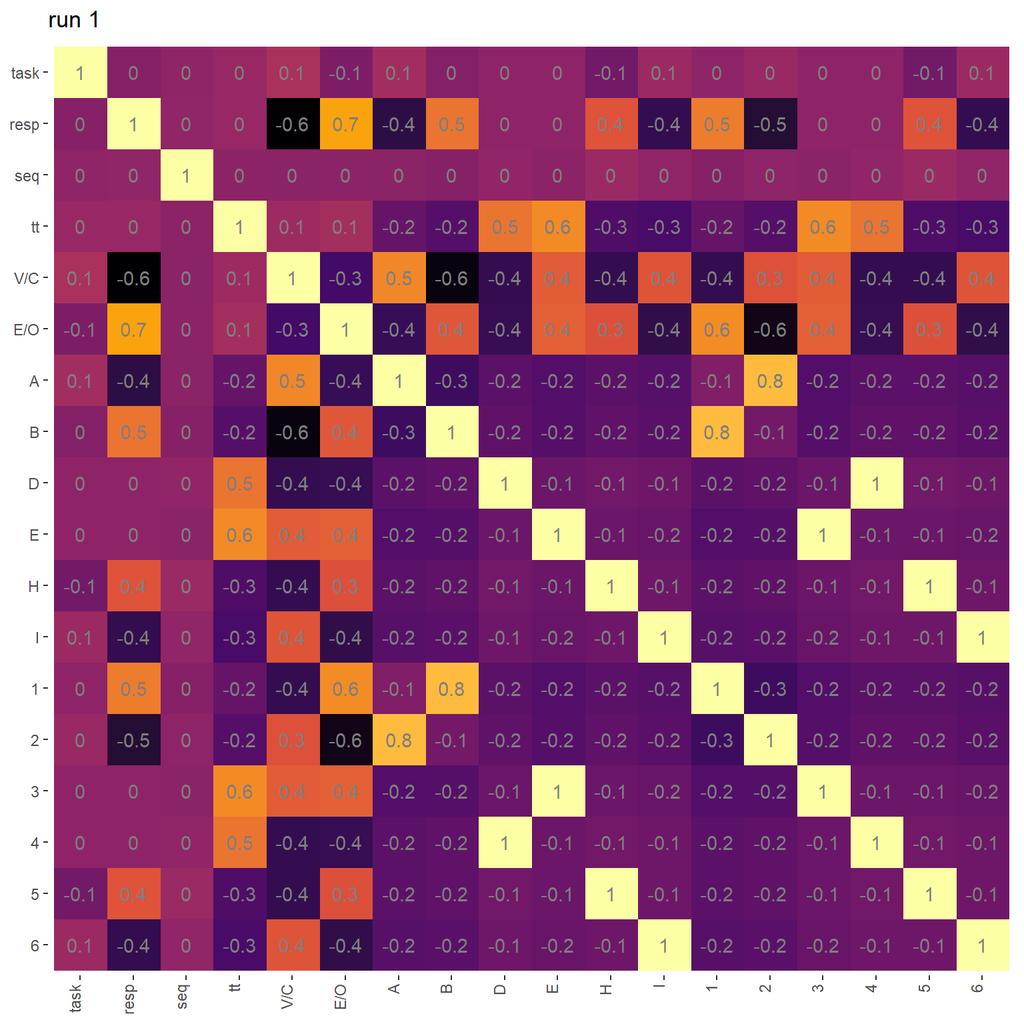

```r
Rbar_cuedts[, , 1] %>%
  symmat4ggplot %>%
  ggplot(aes(v1, v2, fill = value)) +
  geom_raster() +
  geom_text(aes(label = round(value, 1)), color = "grey50") +
  scale_fill_viridis_c(option = "inferno") +
  theme(
    axis.title = element_blank(), axis.text.x = element_text(angle = 90, hjust = 1, vjust = 0),
    panel.background = element_blank(), legend.position = "none"
    ) +
  labs(title = "run 1")
```

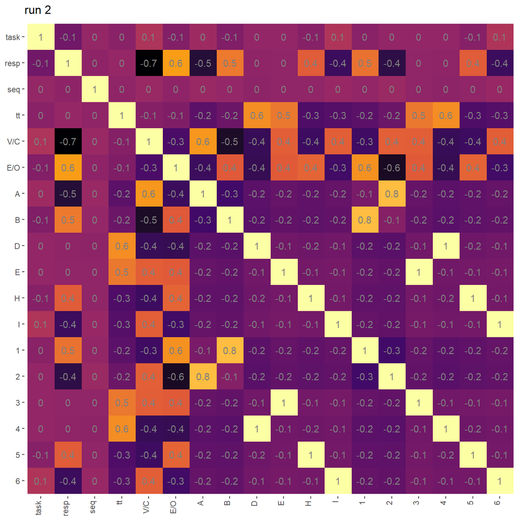

```r
Rbar_cuedts[, , 2] %>%
  symmat4ggplot %>%
  ggplot(aes(v1, v2, fill = value)) +
  geom_raster() +
  geom_text(aes(label = round(value, 1)), color = "grey50") +
  scale_fill_viridis_c(option = "inferno") +
  theme(
    axis.title = element_blank(), axis.text.x = element_text(angle = 90, hjust = 1, vjust = 0),
    panel.background = element_blank(), legend.position = "none"
    ) +
  labs(title = "run 2")
```

Matrices display correlations of factors, averaged across subjects for each run. Letters (A, B, D, E, H, I) indicate the presence of a letter within the probe; likewise for numbers 1–6. Factors in upper left corner (task, resp, seq, tt, V/C, E/O) represent contrasts between levels.

Some key notes:

# 3 Stroop

## 3.1 potential task variables

- target ID: black, blue, green, pink, purple, red, white, yellow
- distractor ID: BLACK, BLUE, GREEN, PINK, PURPLE, RED, WHITE, YELLOW
- pc: PC50, MC
- congruency: incon, congr

## 3.2 counts

Counts per subject*run.

```r
colMeans(with(stroop, table(interaction(subj, run), interaction(trial.type, pc)))) %>%
  kable(col.names = "count", caption = "cue \\* probe type")
```

|  | count |
| --- | --- |
| Con.bias | 54 |
| InCon.bias | 18 |
| Con.PC50 | 18 |
| InCon.PC50 | 18 |

```r
stroop.stim1 <- as.matrix(with(stroop[stroop$run == 1, ], table(subj, item)))
stroop.stim2 <- as.matrix(with(stroop[stroop$run == 2, ], table(subj, item)))

data.frame(
  mean_count = colMeans(stroop.stim1),
  min = apply(stroop.stim1, 2, min),
  max = apply(stroop.stim1, 2, max)
  ) %>%
  kable(caption = "stimulus ID, RUN 1")
```

stimulus ID, RUN 1

|  | mean_count | min | max |
| --- | --- | --- | --- |
| blackBLACK | 3 | 3 | 3 |
| blackPINK | 3 | 3 | 3 |
| blackYELLOW | 3 | 3 | 3 |
| blueBLUE | 15 | 15 | 15 |
| blueWHITE | 3 | 3 | 3 |
| greenBLACK | 3 | 3 | 3 |
| greenGREEN | 6 | 6 | 6 |
| pinkGREEN | 3 | 3 | 3 |
| pinkPINK | 3 | 3 | 3 |
| pinkYELLOW | 3 | 3 | 3 |
| purpleBLUE | 3 | 3 | 3 |
| purplePURPLE | 15 | 15 | 15 |
| redBLUE | 3 | 3 | 3 |
| redPURPLE | 3 | 3 | 3 |
| redRED | 12 | 12 | 12 |
| whitePURPLE | 3 | 3 | 3 |
| whiteRED | 3 | 3 | 3 |
| whiteWHITE | 12 | 12 | 12 |
| yellowGREEN | 3 | 3 | 3 |
| yellowYELLOW | 6 | 6 | 6 |

```r
data.frame(
  mean_count = colMeans(stroop.stim2),
  min = apply(stroop.stim2, 2, min),
  max = apply(stroop.stim2, 2, max)
  ) %>%
  kable(caption = "stimulus ID, RUN 2")
```

stimulus ID, RUN 2

|  | mean_count | min | max |
| --- | --- | --- | --- |
| blackBLACK | 6 | 6 | 6 |
| blackGREEN | 3 | 3 | 3 |
| blueBLUE | 12 | 12 | 12 |
| bluePURPLE | 3 | 3 | 3 |
| blueRED | 3 | 3 | 3 |
| greenGREEN | 3 | 3 | 3 |
| greenPINK | 3 | 3 | 3 |
| greenYELLOW | 3 | 3 | 3 |
| pinkBLACK | 3 | 3 | 3 |
| pinkPINK | 6 | 6 | 6 |
| purplePURPLE | 12 | 12 | 12 |
| purpleRED | 3 | 3 | 3 |
| purpleWHITE | 3 | 3 | 3 |
| redRED | 15 | 15 | 15 |
| redWHITE | 3 | 3 | 3 |
| whiteBLUE | 3 | 3 | 3 |
| whiteWHITE | 15 | 15 | 15 |
| yellowBLACK | 3 | 3 | 3 |
| yellowPINK | 3 | 3 | 3 |
| yellowYELLOW | 3 | 3 | 3 |

```r
#
# stroop.items <- sort(unique(stroop$item))
# R_stroop <-
#   array(
#     NA,
#     dim = c(length(stroop.items), length(stroop.items), length(subjs), 2),
#     dimnames = list(stroop.items, stroop.items, subjs, c("run1", "run2"))
#     )
#
# for (subj.i in seq_along(subjs)) {
#   for (run.i in 1:2) {
#
#     ## get model matrix
#
#     item.factor <- model.matrix(~ as.factor(unlist(stroop[stroop$subj == subjs[subj.i] & stroop$run == run.i, "item"])) - 1)
#     colnames(item.factor) <- stroop.items
#
#     ## get correlations of factors
#
#     contrs <- matrix(nrow = nrow(cuedts.facts), ncol = length(names.facts))
#     colnames(contrs) <- names.facts
#
#     for (ii in seq_along(names.facts)) {
#       # ii = 1
#
#       cols <- (ii + ii - 1)
#       cols <- c(cols, cols + 1)
#       contrs[, names.facts[ii]] <- cuedts.facts[, cols] %*% rbind(-1, 1)
#
#     }
#
#     cuedts.facts <- cbind(contrs, cuedts.facts[, -(1:(length(names.facts)*2))])
#
#
#     ## save correlation matrix
#
#     R_cuedts[, , subj.i] <- cor(cuedts.facts)
#
#   }
# }
#
# Rbar_cuedts <- tanh(apply(atanh(R_cuedts), 1:2, mean))
# # Rbar_cuedts <- apply(R_cuedts, 1:2, mean)
#
# Rbar_cuedts %>%
#   cor %>%
#   symmat4ggplot %>%
#   ggplot(aes(v1, v2, fill = value)) +
#   geom_raster() +
#   geom_text(aes(label = round(value, 1)), color = "grey50") +
#   scale_fill_viridis_c(option = "inferno") +
#   theme(
#     axis.title = element_blank(), axis.text.x = element_text(angle = 90, hjust = 1, vjust = 0),
#     panel.background = element_blank(), legend.position = "none"
#     )
```

# 4 Sterm

## 4.1 potential task variables

## 4.2 counts

```r
stern.load01.trial.type <- as.matrix(with(stern, table(interaction(subj, run), load01.trial.type)))

data.frame(
  mean_count = colMeans(stern.load01.trial.type),
  min = apply(stern.load01.trial.type, 2, min),
  max = apply(stern.load01.trial.type, 2, max)
  ) %>%
  kable(caption = "load01 trialtype")
```

load01 trialtype

|  | mean_count | min | max |
| --- | --- | --- | --- |
| LL5NN | 6.0 | 6 | 6 |
| LL5NP | 9.0 | 9 | 9 |
| LL5RN | 3.0 | 3 | 3 |
| not5NN | 12.0 | 12 | 12 |
| not5NP | 13.5 | 13 | 14 |
| not5RN | 1.5 | 1 | 2 |

```r
stern.load.trial.type <- as.matrix(with(stern, table(interaction(subj, run), interaction(load, trial.type))))

data.frame(
  mean_count = colMeans(stern.load.trial.type),
  min = apply(stern.load.trial.type, 2, min),
  max = apply(stern.load.trial.type, 2, max)
  ) %>%
  kable(caption = "load01 trialtype")
```

|  | mean_count | min | max |
| --- | --- | --- | --- |
| 5.NN | 6.0 | 6 | 6 |
| 6.NN | 2.5 | 2 | 3 |
| 7.NN | 4.0 | 4 | 4 |
| 8.NN | 5.5 | 5 | 6 |
| 5.NP | 9.0 | 9 | 9 |
| 6.NP | 2.0 | 2 | 2 |
| 7.NP | 4.5 | 4 | 5 |
| 8.NP | 7.0 | 7 | 7 |
| 5.RN | 3.0 | 3 | 3 |
| 6.RN | 0.0 | 0 | 0 |
| 7.RN | 0.5 | 0 | 1 |
| 8.RN | 1.0 | 1 | 1 |